# Intestinal Activity in Critically Ill vs Healthy Patients

Rmarkdown Parameter Activity

Enya Dewars

In this project, I wanted to understand more about the bowel movements between critically ill trauma patients and healthy patients as well get an insight on what general gastrointestinal activity looks like. In this study, they state that “delayed grastric emptying is a well-known problem in critically ill patients and its associated with feeding disturbances…” They used a “smart pill” to moniter and calculate the activity in the GI. This pill was able to capture transit times of bowel movements as well as the pH of the specific parts of the intestine.

Looking at the Gastric Emptying time in ill patients versus healthy patients

**1st graph compares pH across different sections of the intestines; between the colon, the small bowel, and the stomach.**

**2nd graph is looking at the mean peak amplitudes which is the sum of amplitudes divided by the number of contractions in a healthy individuals in colon, stomach and small bowel.**

**The 3rd graph I wanted to ask, what is the average whole gut time from ingestion to exiting the body between healthy and ill individuals**

**4th graph asks, what is the average Small Bowel transit time from the gastric emptying to the ileocecal junction between Healthy individuals and Ill individuals**

**5th graph asks, what is the average Gastric Emptying time between Healthy individuals and Ill individuals; Gastric emptying time is the time from ingestion to gastric emptying.**

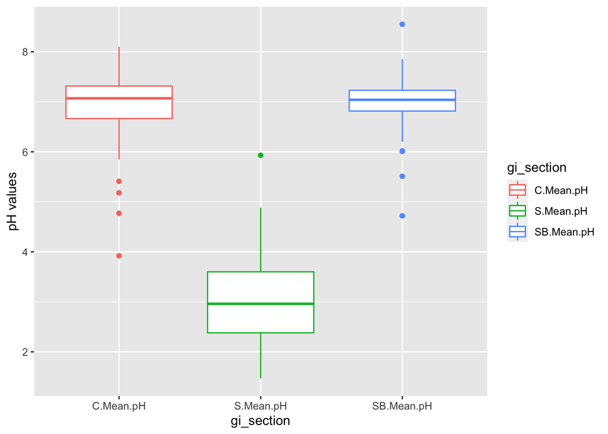

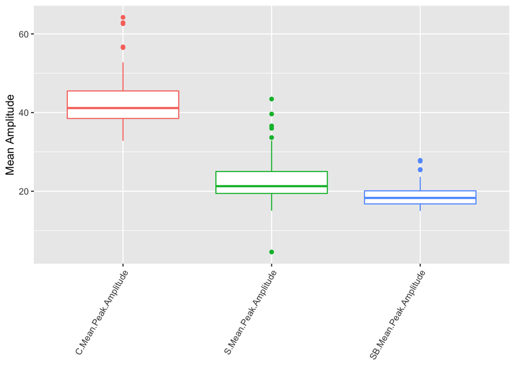

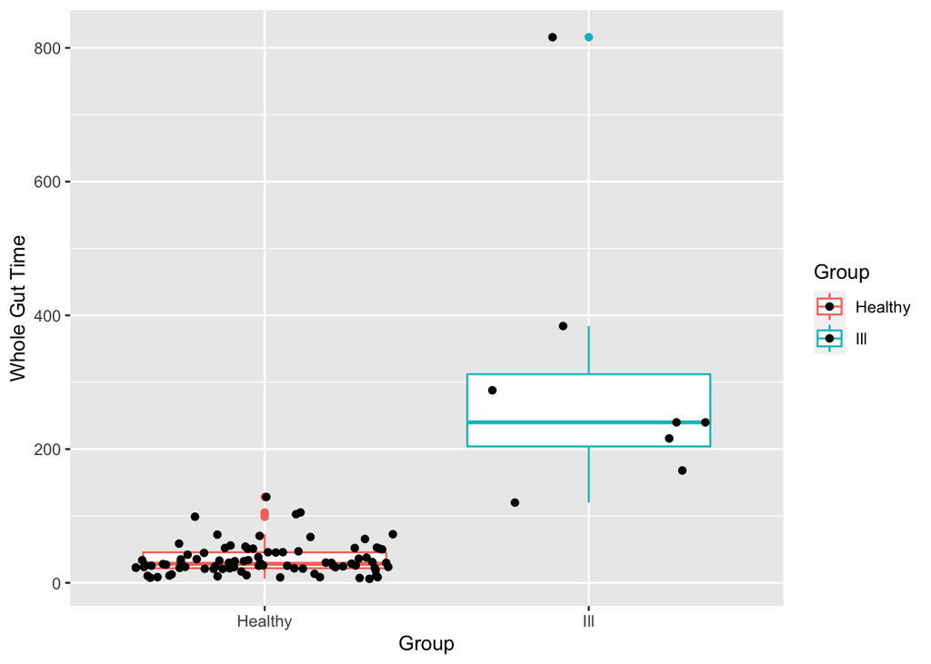

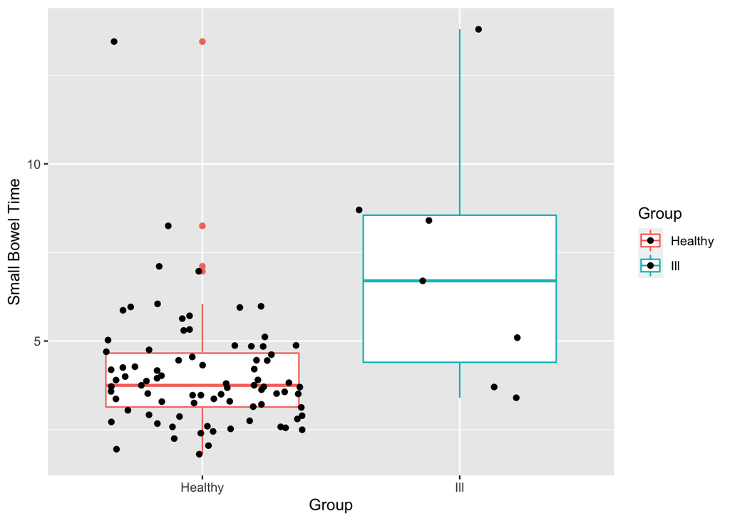

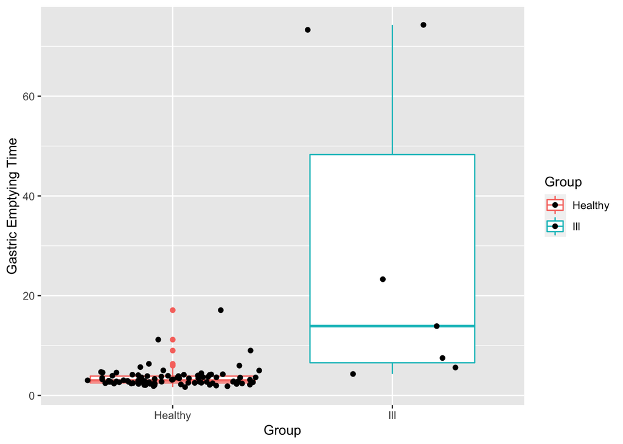

**Based on these graphs, in the last three graphs when measuring gut movement, we see in each instance that it always takes longer in the critically ill patients which was expected. Additionally I was also pleased to see that among the healthy patients there was a difference in pH’s between the colon, the stomach and the small bowels with the colon and small bowel being very similar to eachother.**

```r
#ex: ggplot(cyto, aes(x = diagnosis)) + geom_bar(aes(color=diagnosis))
#glimpse(colon_smallbowel_stomach_pH)


#colon_smallbowel_stomach_pH <- colon_smallbowel_stomach_pH %>%
  #mutate(SB.Mean.pH_Average= mean(SB.Mean.pH)) %>%
  #mutate(S.Mean.pH_Average= mean(S.Mean.pH)) %>%
  #mutate(C.Mean.pH_average=mean(C.Mean.pH)) %>%
  #glimpse()

#colon_smallbowel_stomach_pH <- smartpill %>%
 # select(SB.Mean.pH, S.Mean.pH, C.Mean.pH) %>%
  #drop_na(SB.Mean.pH, S.Mean.pH, C.Mean.pH) %>%
  #glimpse()
```

```r
#See if there is a correlation between Stomach Contractions and Stomach pH

#StomachContractVS_S.pH <-
  #Stoma %>%
  #pivot_longer(cols = contains("pH"), names_to = "gi_section", values_to = "ph")

#StomachContractVS_S.pH <-StomachContractVS_S.pH %>%
 # mutate(S.Contract_vs_S.pH = S.Contractions/S.Mean.pH) %>%
  #glimpse()

 #arrange(desc(time.to.transplant.years))


#ggplot(StomachContractVS_S.pH) + geom_qq(aes(x=S.Contractions, y= S.Mean.pH))
# how do i graph these two
```

install.packages(“medicaldata”) install.packages(“patchwork”) install.packages(“cowplot”) install.packages(“paletteer”) install.packages(“tidyverse”) install.packages(“ggplot2”)